# Do the Crime, Serve the Time? The Effect of Truth-in-Sentencing Laws on Time Served

# 1 Introduction

This paper looks at how TIS impacted total absolute time served for a prison stint (hereafter ‘time served’), the proportion of a sentence served (hereafter ‘proportion served’), and recidivism.

Others have measured the effects of truth-in-sentencing laws. But they are limited by the scope of the sample or are potentially biased due to omitted variables (in other words only establish correlations). I add the existing literature by showing causality using a national sample and DiD. Additionally, the period studied in previous studies was often not long enough to allow conclusions to be made about the effects of TIS on recidivism. By using data through 2007, my sample period is long enough to allow me to observe recidivism for all buy the longest sentences served under TIS. [^1]

# 2 Literature review

My research question is two-fold. First, did TIS laws have an affect on incarceration? Second, did it lead to an effect on recidivism? The first question involves the effect of TIS on incarceration. The second question involves how recidivism responds to changes in incarceration. Each of these questions has been addressed in prior literature, but are limited in scope (or, sample) or rigor. To overcome these limitations, I use a sample of several states while accounting for differences in state sentencing guidelines . This paper is the first to study how TIS affects recidivism.

Two papers employ a DiD framework similar to the one used in this paper. However, rather than focusing on incarceration and recidivism, these papers study how TIS changed sentencing. Owens (2011) finds that offenders who are arrested for TIS-eligible crimes but plead guilty to TIS-ineligible misdemeanors still face longer sentences. This indicates that TIS increases punishment for all violent offenders, not just those explicitly subject to the law. Thus, the effects of TIS spread beyond the crimes explicitly addressed by TIS. Tsuchimoto and Dusek (2009) conduct a similar analysis but find that sentencing practices actually mitigate TIS by reducing the probability an arrested offender is convicted and reducing imposed sentences.

Shepherd (2002) studies how TIS laws effect police, prosecutors, and criminals. She derives a theoretical model to provide context for an empirical analysis. She estimates a system of equations using a two-stage weighted least squares regression. She finds that TIS laws decrease most violent crimes while increasing some lesser crimes like burglaries and autotheft. Long 2018 finds similar effects using a DiD design.

Researchers have studied how time served affects recidivism. Kuziemko (2013) uses a mass release of prisoners and discontinuities in sentencing guidelines to study how time served affects recidivism in the state of Georgia. She finds that extra time spent in prison lowers recidivism. Rose and Shem-Tov (2018) use discontinuities in sentencing guidelines and find similarly signed but larger effects than Kuziemko. Estelle and Phillips (2018) also use discontinuities in sentencing guidelines, in addition to random assignment to judges. The sample contains two types of felony offenders in Michigan. Their findings, which vary across type of conviction, find that harsher sentencing guidelines lead to fewer future crimes, but harsher judges have no effect on recidivism. [^2]

# 3 Institutional Background

## 3.1 Criminal Justice in the US

By the end of the 1970s, state sentencing practices were under heavy criticism for being inconsistent and lenient; This dissatisfaction lead many states to reform the structure of sentencing. Throughout the 1970s, states generally had indeterminate sentencing policies that gave judges full discretion in sentencing. Meanwhile, these sentences were not binding. Prisoners were often released early due to good behavior. This meant that rather than serving time in prison many people instead served a majority of their sentences on parole or other forms of community supervision. Public criticism mounted and pressure to fix an inefficient system led states to become ‘tough on crime’, a catchall phrase referring to policies aimed at reducing crime through increased surveillance and punishment. Several of these policies reduced judge discretion with the goal of uniformity in sentencing. States implemented sentencing guidelines, three-strikes laws, repeat offender laws, and mandatory minimums. Sentencing guidelines reduce judge discretion by limiting the maximum and minimum sentences that may be handed down. These limits, or guidelines, depend on the type of crime committed the circumstances surrounding it. Mandatory minimums are similar to sentencing guidelines, but they only stipulate a minimum sentence. Three-strikes and repeat offender laws made sentencing more uniform and stricter for people that have prior convictions. [^3]

## 3.2 Truth-In-Sentencing

The Federal government also touted a ‘tough on crime’ agenda, culminating in the largest crime bill in U.S. history, the Violent Crime Control and Law Enforcement Act of 1994 (Hereafter “the Crime Bill”). Title II of the Crime Bill is the Violent Offender Incarceration and Truth-in-Sentencing Incentive Grants Program (VIO/TIS grants). It provides grants to states that require violent offenders to serve 85% of their sentence, or show adequate effort to do so. States could receive federal VIO/TIS grant money by legislating this requirement, or by showing that on average violent offenders serve at least 85% of their sentence. These grants were meant to incentivize states to adopt federal sentencing practices by funding prison capacity maintenance or expansion. For states that had determinate sentencing in place, a single sentence is available as the base for the percentage requirements. In states with indeterminate sentencing, the requirement is applied to the maximum sentence. (Sabol et al, 2002)

Among the states that received federal grant money, there are varying degrees to which they needed to alter their sentencing laws to meet the 85% requirement. Many states already had regulations that met or surpassed the requirement and so were automatically eligible for the TIS grant without needing to make any changes. Some states had TIS in place, but the percentage requirement was below 85% and so only needed to make incremental changes to their existing laws. Other states made incremental changes and at the same time abolished parole. Finally, the states that made the largest changes are those that had no previous TIS requirements. Along with differing previous sentencing practices, states varied in how they applied TIS. Some stuck to the 85% requirement for violent offenders described in the Crime Bill, others implemented further (up to 100%) and wider (covering other types of crimes) versions. A total of 28 states and the District of Columbia received TIS grants between 1996 and 1999 (Sabol et al, 2002)

# 4 Data

I use National Crime Reporting Program (NCRP) data provided by the NADJC. This is considered “the most detailed centralized source of information on prison inmates available” (Pfaff 2009). Observations are individual prison stints with an assigned offender number so that the same offender can be linked across multiple stints. Variables include offender characteristics (e.g., unique ID number, date of birth, race, sex), sentence characteristics (e.g., county where sentence imposed, offenses, sentence length), date and type of admission to prison, and date and type of release from prison.

Table 4.1: TIS Information

State

TIS Year

Pct. Required

Offenses Affected

Determinate

Indeterminate

Year Parole Abolished

Source

California

1994

85

violent

✔

http://webcache.googleusercontent.com/search?q=cache:pkWIrpevgMQJ:www.ncrp.info/StateFactSheets.aspx%3Fstate%3DCA+&cd=10&hl=en&ct=clnk&gl=us

Colorado

✔

https://leg.colorado.gov/sites/default/files/ip_-_overview_of_colorado_sentencing_scheme.pdf

Georgia

1995

85

violent

✔

Illinois

1995

85

violent

✔

1978

https://www.ojp.gov/pdffiles1/nij/grants/195163.pdf

Kentucky

1998

85

violent

✔

http://webcache.googleusercontent.com/search?q=cache:Va-Do1cBdfsJ:www.ncrp.info/StateFactSheets.aspx%3Fstate%3DKY+&cd=10&hl=en&ct=clnk&gl=us

Louisiana

1997

85

violent

✔

https://www.ncjrs.gov/pdffiles1/nij/grants/213003.pdf

Michigan

1994

85

violent

✔

Owens (2011)

Minnesota

1993

67

all

✔

1980

http://www.ncrp.info/StateFactSheets.aspx?state=MN

Mississippi

1995

50

violent

✔

1995

http://webcache.googleusercontent.com/search?q=cache:Zm8jQ0k_P84J:www.ncrp.info/StateFactSheets.aspx%3Fstate%3DMI+&cd=12&hl=en&ct=clnk&gl=us

Nebraska

50

all

✔

https://bjs.ojp.gov/content/pub/pdf/tssp.pdf

New Jersey

1997

85

violent

✔

Owens (2011)

New York

1995

violent

✔

Owens (2011)

South Carolina

2005

85

violent

✔

http://webcache.googleusercontent.com/search?q=cache:sCE4YVZ8TYEJ:www.ncrp.info/StateFactSheets.aspx%3Fstate%3DSC+&cd=11&hl=en&ct=clnk&gl=us

Utah

✔

https://www.ojp.gov/pdffiles1/nij/grants/195161.pdf

Wisconsin

2000

100

all

✔

1999

http://webcache.googleusercontent.com/search?q=cache:sL-AeY7ukmsJ:ncrp.info/StateFactSheets.aspx%3Fstate%3DWI+&cd=10&hl=en&ct=clnk&gl=us

## 4.2 Variable Construction

For each offender identification number, I create a recidivate dummy equal to one if a prison stint (including previous jail time) occurs within 1 year of the release date for the previous prison stint. It is important to note that recidivism in this context means people that return to prison. If someone commits a crime and does not go to prison, it is not included in the data.

Table 4.2: Offense Types

| Violent | Property | Drug | Other |
| --- | --- | --- | --- |
| Murder | Burglary | Drug Trafficking | Weapons Offense |
| Unspecified Homicide | Arson | Drug Possession/Use | Driving While Intoxicated |
| Non-negligent Manslaughter | Motor Vehicle Theft | Other Drug Offense | Other |
| Negligent Manslaughter | Fraud |  | Federal Offense |
| Kidnapping | Larceny |  | Blank |
| Sexual Assault | Other Property |  |  |
| Robbery | Stolen Property |  |  |
| Assault |  |  |  |
| Other Violent |  |  |  |

## 4.3 Descriptive Statistics

Here are the main descriptive statistics. For slightly more detailed information refer to the appendix data section.

Table 4.3: Outcome Statistics by State - All Years

| State | Num. Obs. | Mean Time Served | Mean Proportion Served | Mean Recidivism | Std. Dev. Time Served | Std. Dev. Proportion Served | Median Time Served | Median Proportion Served |
| --- | --- | --- | --- | --- | --- | --- | --- | --- |
| California | 785,184 | 31 | 0.74 | 0.01 | 33 | 0.77 | 21 | 0.67 |
| Colorado | 56,926 | 43 | 1.09 | 0.01 | 41 | 0.88 | 30 | 0.88 |
| Georgia | 192,289 | 38 | 0.42 | 0.04 | 42 | 0.44 | 23 | 0.34 |
| Illinois | 356,668 | 21 | 0.36 | 0.03 | 28 | 0.22 | 12 | 0.33 |
| Kentucky | 114,841 | 22 | 0.41 | 0.02 | 26 | 0.29 | 14 | 0.39 |
| Louisiana | 6,213 | 171 | 0.86 | 0.00 | 56 | 1.09 | 162 | 0.84 |
| Michigan | 135,069 | 47 | 0.38 | 0.01 | 46 | 0.57 | 29 | 0.29 |
| Minnesota | 43,866 | 29 | 1.11 | 0.04 | 30 | 2.02 | 18 | 0.67 |
| Mississippi | 5,472 | 132 | 0.78 | 0.01 | 56 | 0.74 | 120 | 0.81 |
| Nebraska | 18,147 | 30 | 0.45 | 0.04 | 34 | 0.23 | 18 | 0.47 |
| New Jersey | 76,960 | 39 | 0.60 | 0.04 | 36 | 1.17 | 29 | 0.58 |
| New York | 240,756 | 40 | 0.55 | 0.01 | 38 | 0.30 | 30 | 0.51 |
| South Carolina | 95,584 | 29 | 0.60 | 0.05 | 40 | 1.18 | 13 | 0.52 |
| Utah | 10,436 | 39 | 0.29 | 0.01 | 40 | 0.27 | 23 | 0.20 |
| Wisconsin | 29,644 | 45 | 0.50 | 0.00 | 45 | 1.07 | 28 | 0.44 |

Notes: Num. Obs. is the total number of prison stints in the sample period. Time served is the time between date of release and date admitted plus the length of time served in jail prior to the date of admission. Proportion served is Time served divided by the sentence length, which is the longest length of time as stated by the court that the offender could be required to serve for all offenses. Recidivism is a dummy equal to one if an offender reenters prison within a year of being released.

Table 4.4: Offender Race, Sex, Type, and Age for All Years- Grouped By State

| State | Percent Black | Percent White | Percent Male | Percent Violent | Percent Property | Percent Drug | Median Age (Rls.) |
| --- | --- | --- | --- | --- | --- | --- | --- |
| California | 0.24 | 0.43 | 0.89 | 0.39 | 0.17 | 0.44 | 33 |
| Colorado | 0.18 | 0.47 | 0.88 | 0.39 | 0.22 | 0.39 | 34 |
| Georgia | 0.63 | 0.35 | 0.90 | 0.45 | 0.18 | 0.37 | 33 |
| Illinois | 0.62 | 0.28 | 0.89 | 0.33 | 0.17 | 0.50 | 31 |
| Kentucky | 0.28 | 0.71 | 0.86 | 0.30 | 0.19 | 0.50 | 32 |
| Louisiana | 0.74 | 0.26 | 0.96 | 0.85 | 0.01 | 0.12 | 44 |
| Michigan | 0.48 | 0.51 | 0.92 | 0.48 | 0.16 | 0.36 | 33 |
| Minnesota | 0.31 | 0.59 | 0.91 | 0.48 | 0.16 | 0.36 | 32 |
| Mississippi | 0.74 | 0.25 | 0.96 | 0.85 | 0.02 | 0.14 | 40 |
| Nebraska | 0.22 | 0.72 | 0.88 | 0.40 | 0.20 | 0.40 | 33 |
| New Jersey | 0.61 | 0.27 | 0.93 | 0.37 | 0.10 | 0.53 | 33 |
| New York | 0.52 | 0.31 | 0.92 | 0.41 | 0.08 | 0.51 | 32 |
| South Carolina | 0.65 | 0.34 | 0.88 | 0.35 | 0.22 | 0.42 | 32 |
| Utah | 0.07 | 0.85 | 0.90 | 0.46 | 0.16 | 0.38 | 36 |
| Wisconsin | 0.46 | 0.50 | 0.92 | 0.50 | 0.09 | 0.41 | 34 |

Table 4.5: Outcome Statistics by State - 1993

| State | Num. Obs. | Mean Time Served | Mean Percent Served | Mean Recidivism | Std. Dev. Time Served | Std. Dev. Percent Served | Median Time Served | Median Percent Served |
| --- | --- | --- | --- | --- | --- | --- | --- | --- |
| California | 43,439 | 31 | 0.73 | 0.0115 | 34 | 0.49 | 20 | 0.64 |
| Colorado | 337 | 148 | 1.92 | 0.0178 | 58 | 3.04 | 132 | 0.80 |
| Georgia | 9,412 | 38 | 0.48 | 0.0328 | 47 | 0.58 | 22 | 0.38 |
| Illinois | 16,651 | 26 | 0.36 | 0.0219 | 36 | 0.27 | 15 | 0.34 |
| Kentucky | 4,515 | 25 | 0.44 | 0.0140 | 33 | 0.26 | 14 | 0.46 |
| Louisiana | 157 | 279 | 0.63 | 0.0000 | 16 | 0.28 | 279 | 0.56 |
| Michigan | 6,272 | 61 | 0.40 | 0.0061 | 61 | 0.49 | 36 | 0.32 |
| Minnesota | 1,798 | 32 | 0.92 | 0.0389 | 37 | 1.45 | 20 | 0.67 |
| Mississippi | 108 | 256 | 0.69 | 0.0000 | 25 | 0.32 | 245 | 0.62 |
| Nebraska | 95 | 133 | 0.51 | 0.0211 | 47 | 0.39 | 120 | 0.50 |
| New Jersey | 335 | 162 | 0.80 | 0.0149 | 45 | 1.03 | 145 | 0.56 |
| New York | 13,171 | 48 | 0.50 | 0.0062 | 46 | 0.26 | 32 | 0.50 |
| South Carolina | 666 | 129 | 0.54 | 0.0165 | 50 | 0.22 | 113 | 0.51 |
| Utah | 78 | 131 | 0.47 | 0.0000 | 46 | 0.34 | 119 | 0.44 |
| Wisconsin | 329 | 132 | 0.77 | 0.0000 | 49 | 0.31 | 118 | 0.65 |

Notes: Statistics are computed only for the year 1993 which is the last preTIS year. Time served is the time between date of release and date admitted plus the length of time served in jail prior to the date of admission. Proportion served is Time served divided by the sentence length, which is the longest length of time as stated by the court that the offender could be required to serve for all offenses. Recidivism is a dummy equal to one if an offender reenters prison within a year of being released.

| State | Percent Black | Percent White | Percent Male | Percent Violent | Percent Property | Percent Drug | Median Age (Rls.) |
| --- | --- | --- | --- | --- | --- | --- | --- |
| California | 0.24 | 0.43 | 0.89 | 0.39 | 0.17 | 0.44 | 33 |
| Colorado | 0.18 | 0.47 | 0.88 | 0.39 | 0.22 | 0.39 | 34 |
| Georgia | 0.63 | 0.35 | 0.90 | 0.45 | 0.18 | 0.37 | 33 |
| Illinois | 0.62 | 0.28 | 0.89 | 0.33 | 0.17 | 0.50 | 31 |
| Kentucky | 0.28 | 0.71 | 0.86 | 0.30 | 0.19 | 0.50 | 32 |
| Louisiana | 0.74 | 0.26 | 0.96 | 0.85 | 0.01 | 0.12 | 44 |
| Michigan | 0.48 | 0.51 | 0.92 | 0.48 | 0.16 | 0.36 | 33 |
| Minnesota | 0.31 | 0.59 | 0.91 | 0.48 | 0.16 | 0.36 | 32 |
| Mississippi | 0.74 | 0.25 | 0.96 | 0.85 | 0.02 | 0.14 | 40 |
| Nebraska | 0.22 | 0.72 | 0.88 | 0.40 | 0.20 | 0.40 | 33 |
| New Jersey | 0.61 | 0.27 | 0.93 | 0.37 | 0.10 | 0.53 | 33 |
| New York | 0.52 | 0.31 | 0.92 | 0.41 | 0.08 | 0.51 | 32 |
| South Carolina | 0.65 | 0.34 | 0.88 | 0.35 | 0.22 | 0.42 | 32 |
| Utah | 0.07 | 0.85 | 0.90 | 0.46 | 0.16 | 0.38 | 36 |
| Wisconsin | 0.46 | 0.50 | 0.92 | 0.50 | 0.09 | 0.41 | 34 |

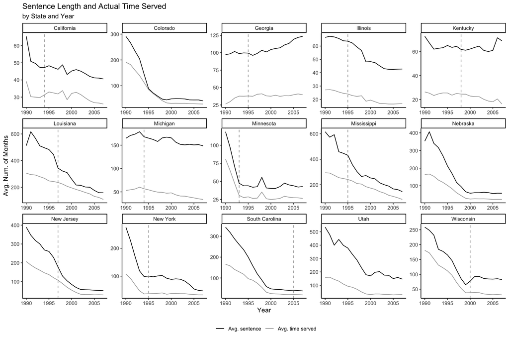

Figure 4.1: Avg. sentence length and Avg. actual time served (Months) by state. Sentence length is he longest length of time as stated by the court that the offender could be required to serve for all offenses. Prison stints with a sentence length or time served of ‘zero’ are exluded, as are stints with proportions greater than 2. Time served is the time between date of release and date admitted plus the length of time served in jail prior to the date of admission to prison and credited to prison service for the current sentence. The dotted vertical line indicates the year TIS was introduced.

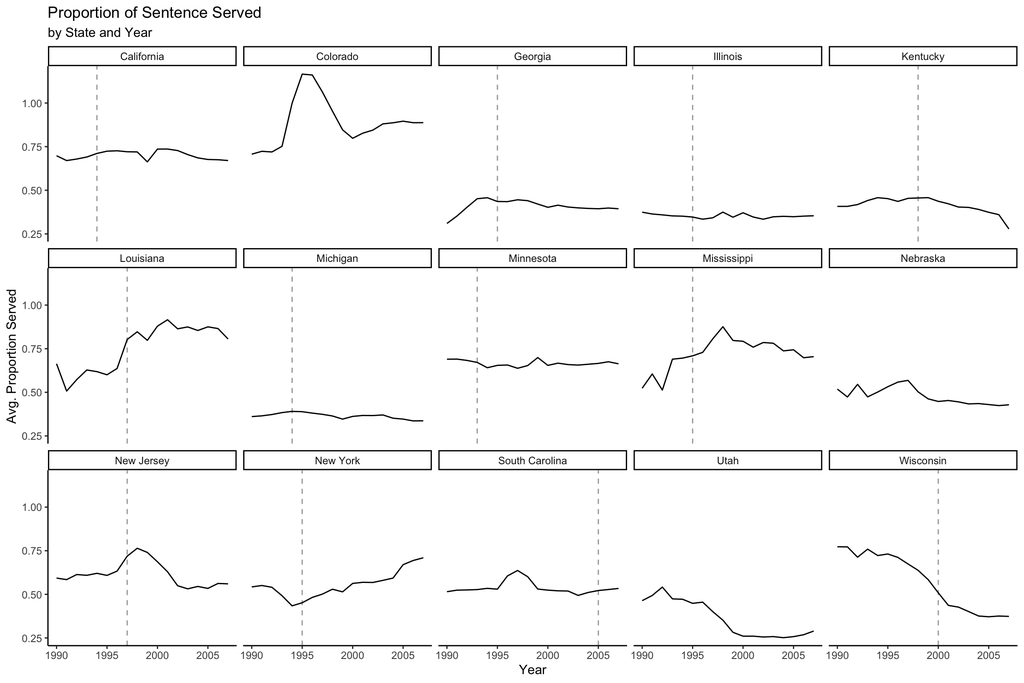

Figure 4.2: Avg. proportion of sentence served by state and year. Sentence length is he longest length of time as stated by the court that the offender could be required to serve for all offenses. Prison stints with a sentence length or time served of ‘zero’ are exluded, as are stints with proportions greater than 2. Time served is the time between date of release and date admitted plus the length of time served in jail prior to the date of admission. The dotted vertical line indicates the year TIS was introduced.

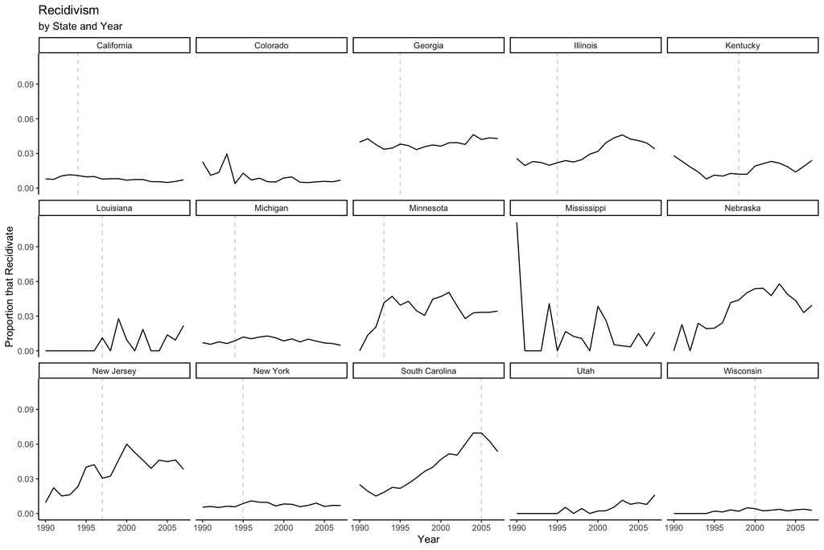

Figure 4.3: Recidivism is coded as a dummy variable equal to 1 if an individual serves another prison stint within 365 days of the previous stint ending.

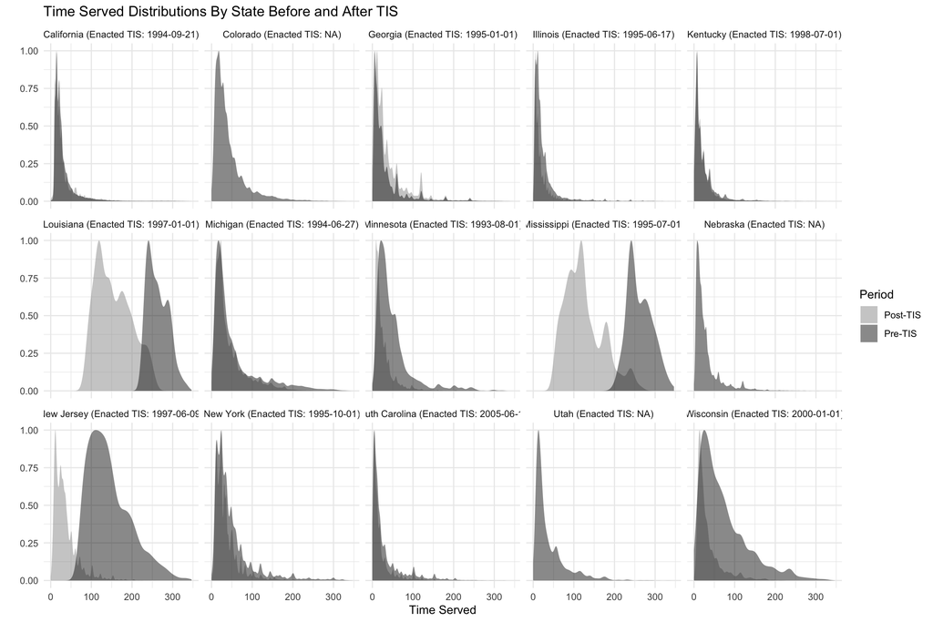

Figure 4.4: Distribution of time served before and after TIS was enacted. States with only one distribution did not enact TIS. Time served is the time between date of release and date admitted plus the length of time served in jail prior to the date of admission.

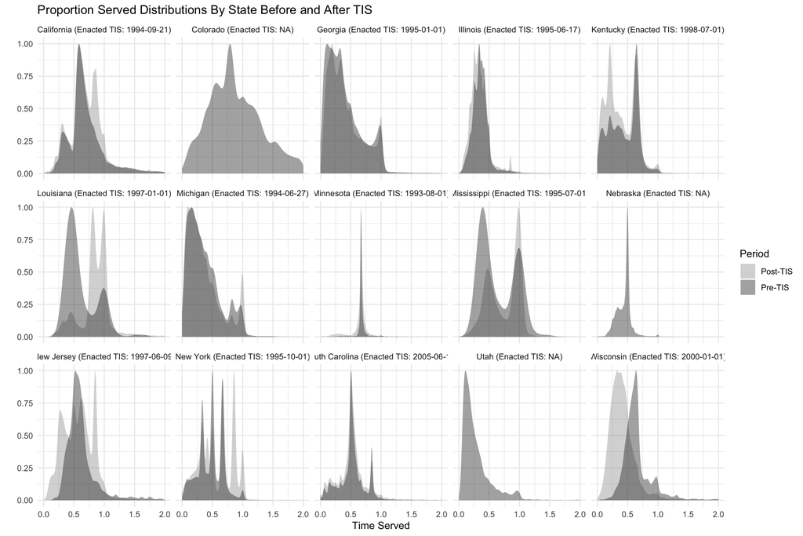

Figure 4.5: Distribution of proportion served before and after TIS was enacted. States with only one distribution did not enact TIS. Sample is limited to observations where the proportion served is less than 2. Proportion served is Time served divided by the sentence length.

# 5 Empirical Method

The following regression equation encapsulates my preferred, event-study specification:

$$\begin{equation}
y_{its} = \gamma_s + \lambda_t + \sum_{\tau=-q}^{-2} \gamma_{\tau} D_{s\tau} + \sum_{\tau=0}^m \delta_{\tau} D_{s\tau} + X_{ist} + \epsilon_{ist}
(\#eq:es_con)
\end{equation}$$

Where, $i, t$ and $s$ represent individual, year, and state. $y_{its}$ is the outcome of interest – time served, proportion served, or a recidivate dummy. $\gamma_s$ and $\lambda_t$ are fixed effects for the state and year in which an inmate was admitted. $\sum_{\tau=-q}^{-2} D_{s\tau}$ is a set of relative time dummies for years leading up to the TIS policy. Because $\gamma_{\tau}$ are coefficients leading up to the policy, we would expect them to be close to zero. Similarly, $\sum_{\tau=0}^m D_{s\tau}$ relative time dummies for the years following TIS. $\delta_{\tau}$ are measure the effects of TIS in the years following the policy and are our coefficients of interest. Note that these dummies measure the difference between each relative time period and the period directly preceding the year of TIS (that is, I omit $\tau = -1$). [^6] I set $q = m = 6$ by setting relative periods that are more than six years away equal to six.] Although the window is symmetric, it is an unbalanced panel because most states start TIS before 1996 or after 2001. $X_{ist}$ is a matrix of controls at the observation level. It consists of demographics variables – age at release, race, and sex; and offense variables – Type and location of agency that assumes custody of the person upon release, the type of release, the facility released from, and offense category. $\epsilon_{ist}$ is the idiosyncratic error term.

$$\begin{equation}
y_{its} = \gamma_s + \lambda_t + \beta_1 treatment_{st} + X_{ist} + \epsilon_{ist}
(\#eq:did_con)
\end{equation}$$

# 6 Main Results

## 6.1 Time Served

Model 1: Event Study with controls - Time Served

| Outcome: | Time served (months) All | Time served (months) Violent | Time served (months) Property | Time served (months) Drug |
| --- | --- | --- | --- | --- |
| **Years Prior** |  |  |  |  |
| -6 | 1.98 | −0.34 | 0.78 | 4.84 |
|  | (12.09) | (12.38) | ( 6.64) | (11.01) |
| -5 | −0.99 | −3.46 | 0.69 | 1.39 |
|  | ( 7.76) | ( 7.78) | ( 3.99) | ( 6.88) |
| -4 | −2.01 | −4.55 | 0.37 | 0.19 |
|  | ( 5.18) | ( 5.26) | ( 2.84) | ( 3.96) |
| -3 | −2.67 | −4.95 | −0.19 | −0.75 |
|  | ( 3.42) | ( 3.61) | ( 1.86) | ( 2.25) |
| -2 | −2.43 | −3.44+ | −0.94 | −1.67 |
|  | ( 1.74) | ( 1.84) | ( 0.93) | ( 1.37) |
| **Years Post** |  |  |  |  |
| 0 | 2.72+ | 4.24* | 1.20 | 1.32 |
|  | ( 1.51) | ( 1.81) | ( 0.81) | ( 1.07) |
| 1 | 4.80+ | 7.17* | 2.07 | 2.24 |
|  | ( 2.78) | ( 3.19) | ( 1.38) | ( 1.90) |
| 2 | 7.09+ | 10.28* | 3.28 | 3.12 |
|  | ( 4.10) | ( 4.59) | ( 2.09) | ( 2.82) |
| 3 | 10.46+ | 14.17* | 6.38+ | 4.92 |
|  | ( 5.94) | ( 6.40) | ( 3.56) | ( 4.26) |
| 4 | 12.17 | 16.51* | 7.95 | 5.44 |
|  | ( 7.47) | ( 7.53) | ( 4.94) | ( 5.62) |
| 5 | 13.80 | 19.27* | 9.00 | 5.72 |
|  | ( 8.47) | ( 8.24) | ( 5.78) | ( 6.57) |
| 6 | 17.46+ | 24.81** | 11.16+ | 7.06 |
|  | ( 9.05) | ( 8.84) | ( 6.24) | ( 6.74) |
| N | 2,092,752 | 782,179 | 348,839 | 960,732 |
| R. Squared | 0.43 | 0.41 | 0.2 | 0.24 |
| FE: Admit Year | X | X | X | X |
| FE: State | X | X | X | X |

+ p < 0.1, * p < 0.05, ** p < 0.01, *** p < 0.001

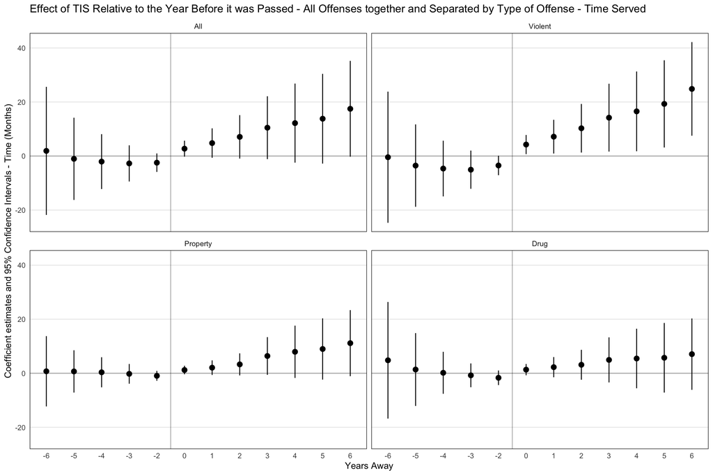

Figure 6.1: Effect of TIS Relative to the Year Before it was Passed - All Offenses together and Separated by Type of Offense - Time Served

## 6.2 Proportion Served

Model 1: Event Study with controls - Proportion Served

| Outcome: | Proportion served All | Proportion served Violent | Proportion served Property | Proportion served Drug |
| --- | --- | --- | --- | --- |
| **Years Prior** |  |  |  |  |
| -6 | −0.04 | −0.03 | −0.08 | −0.02 |
|  | (0.08) | (0.08) | (0.09) | (0.11) |
| -5 | −0.02 | −0.02 | −0.05 | −0.02 |
|  | (0.04) | (0.05) | (0.05) | (0.06) |
| -4 | −0.02 | −0.02 | −0.04 | −0.01 |
|  | (0.03) | (0.04) | (0.04) | (0.05) |
| -3 | −0.02 | −0.01 | −0.04 | −0.01 |
|  | (0.02) | (0.03) | (0.04) | (0.04) |
| -2 | −0.01 | −0.01 | −0.02 | −0.01 |
|  | (0.01) | (0.01) | (0.03) | (0.03) |
| **Years Post** |  |  |  |  |
| 0 | 0.01 | 0.04 | −0.01 | 0.00 |
|  | (0.02) | (0.02) | (0.03) | (0.02) |
| 1 | 0.02 | 0.04 | 0.00 | 0.01 |
|  | (0.04) | (0.04) | (0.07) | (0.05) |
| 2 | 0.04 | 0.05 | 0.01 | 0.03 |
|  | (0.05) | (0.06) | (0.08) | (0.06) |
| 3 | 0.08 | 0.13 | 0.05 | 0.05 |
|  | (0.07) | (0.09) | (0.10) | (0.08) |
| 4 | 0.16 | 0.22 | 0.17 | 0.10 |
|  | (0.14) | (0.17) | (0.18) | (0.14) |
| 5 | 0.22 | 0.26 | 0.32 | 0.16 |
|  | (0.19) | (0.19) | (0.32) | (0.20) |
| 6 | 0.18 | 0.21 | 0.22 | 0.13 |
|  | (0.12) | (0.13) | (0.19) | (0.14) |
| N | 2,091,891 | 781,794 | 348,703 | 960,392 |
| R. Squared | 0.1 | 0.08 | 0.12 | 0.16 |
| FE: Admit Year | X | X | X | X |
| FE: State | X | X | X | X |

+ p < 0.1, * p < 0.05, ** p < 0.01, *** p < 0.001

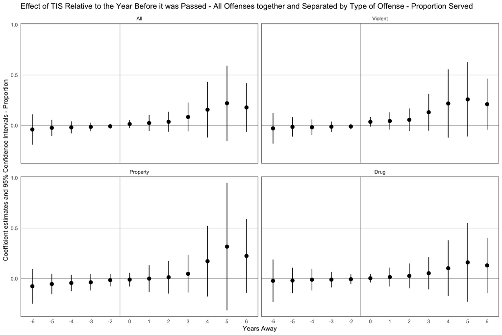

Figure 6.2: Effect of TIS Relative to the Year Before it was Passed - All Offenses together and Separated by Type of Offense - Proportion Served

## 6.3 Recidivism

Model 1: Event Study with controls - Recidivate Dummy

| Outcome: | Recidivism Dummy All | Recidivism Dummy Violent | Recidivism Dummy Property | Recidivism Dummy Drug |
| --- | --- | --- | --- | --- |
| **Years Prior** |  |  |  |  |
| -6 | −0.01* | −0.01* | −0.01+ | −0.01 |
|  | (0.01) | (0.00) | (0.01) | (0.01) |
| -5 | −0.01*** | −0.01** | −0.02** | −0.01* |
|  | (0.00) | (0.00) | (0.01) | (0.00) |
| -4 | −0.01** | −0.01** | −0.01** | −0.01 |
|  | (0.00) | (0.00) | (0.01) | (0.00) |
| -3 | −0.01** | 0.00+ | −0.01+ | −0.01+ |
|  | (0.00) | (0.00) | (0.00) | (0.00) |
| -2 | 0.00* | 0.00+ | 0.00 | 0.00* |
|  | (0.00) | (0.00) | (0.00) | (0.00) |
| **Years Post** |  |  |  |  |
| 0 | 0.00 | 0.00 | 0.00 | 0.00 |
|  | (0.00) | (0.00) | (0.00) | (0.00) |
| 1 | 0.00 | 0.00 | 0.00 | 0.00 |
|  | (0.00) | (0.00) | (0.00) | (0.00) |
| 2 | 0.00 | 0.00 | 0.00 | 0.00 |
|  | (0.00) | (0.00) | (0.00) | (0.00) |
| 3 | 0.00 | 0.00 | 0.00 | 0.00 |
|  | (0.01) | (0.01) | (0.01) | (0.01) |
| 4 | 0.00 | 0.00 | 0.00 | 0.00 |
|  | (0.01) | (0.01) | (0.01) | (0.01) |
| 5 | 0.00 | 0.00 | 0.00 | 0.00 |
|  | (0.01) | (0.01) | (0.01) | (0.01) |
| 6 | 0.00 | 0.00 | 0.00 | 0.00 |
|  | (0.01) | (0.01) | (0.01) | (0.01) |
| N | 2,092,752 | 782,179 | 348,839 | 960,732 |
| R. Squared | 0.02 | 0.02 | 0.03 | 0.03 |
| FE: Admit Year | X | X | X | X |
| FE: State | X | X | X | X |

+ p < 0.1, * p < 0.05, ** p < 0.01, *** p < 0.001

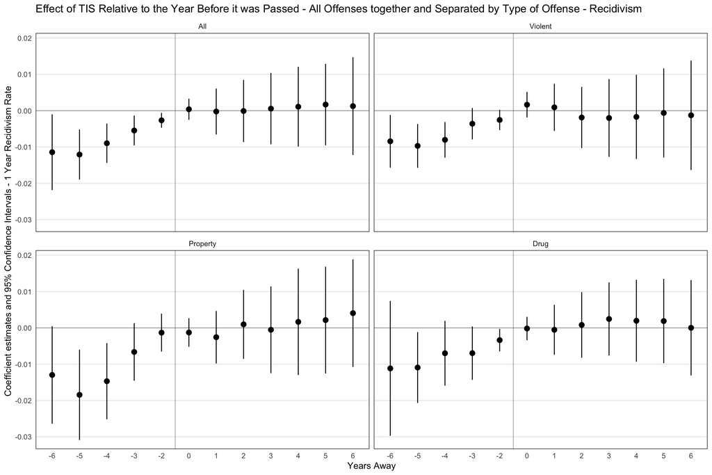

Figure 6.3: Effect of TIS Relative to the Year Before it was Passed - All Offenses together and Separated by Type of Offense - Recidivism

## 6.4 Post vs Pre TIS Comparison

Model 2: Before vs. After with controls.

| Outcome: | Pct. served All | Pct. served Violent | Pct. served Property | Pct. served Drug | Time served (months) All | Time served (months) Violent | Time served (months) Property | Time served (months) Drug |
| --- | --- | --- | --- | --- | --- | --- | --- | --- |
| Post TIS | 0.03 | 0.06** | 0.00 | 0.01 | 4.77 | 8.19* | 1.46 | 2.00 |
|  | (0.04) | (0.02) | (0.02) | (0.01) | ( 2.93) | ( 3.02) | ( 0.96) | ( 1.24) |
| N | 2,091,891 | 781,794 | 348,703 | 960,392 | 2,091,891 | 781,794 | 348,703 | 960,392 |
| R. Squared | 0.1 | 0.07 | 0.12 | 0.15 | 0.42 | 0.41 | 0.19 | 0.24 |
| FE: Admit Year | X | X | X | X | X | X | X | X |
| FE: State | X | X | X | X | X | X | X | X |

+ p < 0.1, * p < 0.05, ** p < 0.01, *** p < 0.001

# 7 Additional Results

Model 3: Event Study with NO controls.

|  | Pct. served All | Pct. served Violent | Pct. served Property | Pct. served Drug | Time served (months) All | Time served (months) Violent | Time served (months) Property | Time served (months) Drug |
| --- | --- | --- | --- | --- | --- | --- | --- | --- |
| **Years Prior** |  |  |  |  |  |  |  |  |
| -6 | −0.01 | −0.01 | −0.05 | 0.03 | 10.42 | 10.66 | 1.53 | 9.70 |
|  | (0.07) | (0.07) | (0.07) | (0.07) | (14.85) | (17.04) | (7.68) | (11.12) |
| -5 | 0.00 | −0.01 | −0.03 | 0.02 | 3.36 | 1.97 | 1.10 | 4.03 |
|  | (0.03) | (0.05) | (0.05) | (0.05) | ( 9.05) | (10.84) | (4.69) | ( 7.56) |
| -4 | −0.01 | −0.02 | −0.03 | 0.02 | −0.32 | −2.33 | 0.71 | 1.75 |
|  | (0.03) | (0.04) | (0.04) | (0.04) | ( 5.58) | ( 7.07) | (3.12) | ( 4.29) |
| -3 | −0.02 | −0.02 | −0.03 | 0.00 | −2.22 | −4.45 | −0.10 | 0.04 |
|  | (0.02) | (0.03) | (0.03) | (0.03) | ( 3.44) | ( 4.66) | (1.74) | ( 2.25) |
| -2 | −0.01 | −0.02 | −0.01 | 0.00 | −2.63 | −3.68 | −1.13 | −1.42 |
|  | (0.02) | (0.02) | (0.03) | (0.02) | ( 1.74) | ( 2.26) | (0.92) | ( 1.41) |
| **Years Post** |  |  |  |  |  |  |  |  |
| 0 | 0.02 | 0.04 | −0.01 | 0.00 | 2.90+ | 4.43* | 1.40 | 0.94 |
|  | (0.02) | (0.03) | (0.03) | (0.02) | ( 1.58) | ( 2.08) | (0.90) | ( 1.01) |
| 1 | 0.03 | 0.05 | −0.01 | 0.00 | 5.24+ | 7.63+ | 2.08 | 1.48 |
|  | (0.04) | (0.05) | (0.06) | (0.04) | ( 3.05) | ( 3.98) | (1.54) | ( 1.83) |
| 2 | 0.03 | 0.06 | −0.01 | 0.01 | 7.62 | 10.75+ | 2.87 | 1.97 |
|  | (0.05) | (0.06) | (0.07) | (0.05) | ( 5.02) | ( 6.15) | (2.34) | ( 2.97) |
| 3 | 0.07 | 0.14 | 0.00 | 0.01 | 11.84 | 16.18+ | 4.96 | 3.04 |
|  | (0.08) | (0.10) | (0.09) | (0.07) | ( 8.26) | ( 9.03) | (3.84) | ( 5.03) |
| 4 | 0.16 | 0.24 | 0.13 | 0.06 | 15.74 | 20.83+ | 7.31 | 4.03 |
|  | (0.15) | (0.15) | (0.18) | (0.13) | (10.95) | (11.42) | (5.31) | ( 6.94) |
| 5 | 0.24 | 0.30+ | 0.30 | 0.13 | 19.55 | 25.91* | 9.31 | 5.03 |
|  | (0.20) | (0.16) | (0.31) | (0.18) | (12.79) | (13.05) | (6.45) | ( 8.53) |
| 6 | 0.22 | 0.26* | 0.22 | 0.11 | 25.65+ | 33.94* | 11.55 | 6.89 |
|  | (0.14) | (0.12) | (0.20) | (0.15) | (13.79) | (14.09) | (7.23) | ( 9.22) |
| N | 2,093,347 | 781,824 | 348,712 | 960,444 | 2,093,347 | 781,824 | 348,712 | 960,444 |
| R. Squared | 0.07 | 0.06 | 0.1 | 0.1 | 0.09 | 0.1 | 0.09 | 0.1 |
| FE: Admit Year | X | X | X | X | X | X | X | X |
| FE: State | X | X | X | X | X | X | X | X |

+ p < 0.1, * p < 0.05, ** p < 0.01, *** p < 0.001

Model 4: Before vs. After with NO controls.

| Outcome: | Pct. served All | Pct. served Violent | Pct. served Property | Pct. served Drug | Time served (months) All | Time served (months) Violent | Time served (months) Property | Time served (months) Drug |
| --- | --- | --- | --- | --- | --- | --- | --- | --- |
| Post TIS | 0.02 | 0.06 | −0.01 | −0.01 | 3.76 | 7.59 | 1.13 | 0.48 |
|  | (0.04) | (0.04) | (0.04) | (0.03) | (4.1) | (6.13) | (1.8) | (1.7) |
| N | 2,093,347 | 781,824 | 348,712 | 960,444 | 2,093,347 | 781,824 | 348,712 | 960,444 |
| R. Squared | 0.07 | 0.06 | 0.1 | 0.1 | 0.08 | 0.09 | 0.08 | 0.1 |
| FE: Admit Year | X | X | X | X | X | X | X | X |
| FE: State | X | X | X | X | X | X | X | X |

+ p < 0.1, * p < 0.05, ** p < 0.01, *** p < 0.001

# 8 References

# 9 Appendix

## 9.1 Appendix - data

Table 9.1: Summary Statistics - violent Offenses

Time Served

Percent Served

State

Stat

Pre-TIS

Post-TIS

Pre-TIS

Post-TIS

Minnesota (Enacted TIS: 1993-08-01)

Total Number

1,967.0

19,041

Mean

56.3

35

0.91

1.16

Std. Dev.

48.8

35

1.19

1.89

1st Quart.

25.0

14

0.66

0.66

Median

41.9

23

0.67

0.68

3rd Quart.

65.9

40

0.69

0.71

Michigan (Enacted TIS: 1994-06-27)

Total Number

15,695.0

49,006

Mean

81.5

63

0.44

0.39

Std. Dev.

68.6

48

0.40

0.41

1st Quart.

29.5

27

0.22

0.19

Median

55.4

49

0.38

0.33

3rd Quart.

118.1

88

0.60

0.53

California (Enacted TIS: 1994-09-21)

Total Number

72,928.0

234,578

Mean

46.3

45

0.81

0.87

Std. Dev.

49.9

42

0.91

1.22

1st Quart.

19.1

18

0.56

0.59

Median

28.8

28

0.67

0.78

3rd Quart.

51.4

58

0.89

0.91

Georgia (Enacted TIS: 1995-01-01)

Total Number

20,999.0

66,305

Mean

54.0

59

0.48

0.50

Std. Dev.

60.4

48

0.47

0.48

1st Quart.

14.8

24

0.21

0.25

Median

30.8

45

0.40

0.43

3rd Quart.

61.4

84

0.69

0.71

Illinois (Enacted TIS: 1995-06-17)

Total Number

37,577.0

79,642

Mean

39.8

33

0.39

0.40

Std. Dev.

48.3

36

0.18

0.21

1st Quart.

13.1

11

0.32

0.29

Median

23.5

20

0.39

0.38

3rd Quart.

42.0

39

0.45

0.46

Mississippi (Enacted TIS: 1995-07-01)

Total Number

442.0

4,187

Mean

260.9

128

0.69

0.77

Std. Dev.

29.9

47

0.66

0.35

1st Quart.

239.9

95

0.39

0.49

Median

251.8

120

0.48

0.92

3rd Quart.

283.9

159

1.00

1.00

New York (Enacted TIS: 1995-10-01)

Total Number

27,346.0

70,617

Mean

71.8

51

0.56

0.73

Std. Dev.

64.6

40

0.31

0.25

1st Quart.

27.0

24

0.37

0.65

Median

48.3

37

0.57

0.84

3rd Quart.

94.8

62

0.67

0.86

Louisiana (Enacted TIS: 1997-01-01)

Total Number

1,100.0

4,212

Mean

263.2

157

0.63

0.93

Std. Dev.

26.0

44

0.28

1.30

1st Quart.

240.5

120

0.46

0.80

Median

258.8

148

0.51

0.85

3rd Quart.

283.6

192

0.77

1.00

New Jersey (Enacted TIS: 1997-06-09)

Total Number

2,480.0

25,670

Mean

148.4

53

0.83

0.70

Std. Dev.

52.6

39

6.83

0.34

1st Quart.

108.2

25

0.48

0.54

Median

138.0

42

0.56

0.74

3rd Quart.

180.7

71

0.66

0.85

Kentucky (Enacted TIS: 1998-07-01)

Total Number

15,233.0

19,637

Mean

38.8

34

0.45

0.44

Std. Dev.

44.1

34

0.29

0.32

1st Quart.

9.5

11

0.25

0.21

Median

24.1

24

0.47

0.42

3rd Quart.

47.6

43

0.64

0.63

Wisconsin (Enacted TIS: 2000-01-01)

Total Number

5,456.0

9,486

Mean

93.7

50

0.75

0.43

Std. Dev.

62.7

40

0.88

0.25

1st Quart.

45.0

20

0.55

0.28

Median

77.1

35

0.63

0.40

3rd Quart.

126.1

66

0.75

0.52

South Carolina (Enacted TIS: 2005-06-17)

Total Number

25,505.0

8,083

Mean

58.2

33

0.66

0.59

Std. Dev.

56.5

34

1.32

0.79

1st Quart.

14.3

10

0.47

0.40

Median

35.8

19

0.53

0.52

3rd Quart.

92.6

43

0.75

0.66

Table 9.2: Summary Statistics - property Offenses

Time Served

Percent Served

State

Stat

Pre-TIS

Post-TIS

Pre-TIS

Post-TIS

Minnesota (Enacted TIS: 1993-08-01)

Total Number

245.0

6,915.0

Mean

22.8

13.9

1.34

1.32

Std. Dev.

20.6

11.5

6.39

2.68

1st Quart.

12.6

8.3

0.66

0.64

Median

17.2

11.2

0.68

0.68

3rd Quart.

27.0

15.0

0.71

0.73

Michigan (Enacted TIS: 1994-06-27)

Total Number

5,757.0

16,294.0

Mean

28.3

26.1

0.38

0.31

Std. Dev.

25.9

22.0

0.29

0.25

1st Quart.

13.2

13.0

0.18

0.13

Median

21.0

19.8

0.32

0.23

3rd Quart.

33.3

30.2

0.52

0.41

California (Enacted TIS: 1994-09-21)

Total Number

23,339.0

110,988.0

Mean

20.7

21.1

0.67

0.67

Std. Dev.

17.4

17.5

0.35

0.36

1st Quart.

13.0

11.6

0.52

0.52

Median

17.0

15.6

0.63

0.64

3rd Quart.

23.4

24.3

0.79

0.82

Georgia (Enacted TIS: 1995-01-01)

Total Number

7,474.0

26,657.0

Mean

15.6

21.4

0.40

0.40

Std. Dev.

16.6

19.8

0.46

0.38

1st Quart.

5.8

9.4

0.17

0.17

Median

11.6

15.9

0.31

0.32

3rd Quart.

20.5

24.8

0.52

0.54

Illinois (Enacted TIS: 1995-06-17)

Total Number

14,731.0

45,627.0

Mean

14.3

12.4

0.34

0.33

Std. Dev.

13.7

12.1

0.25

0.20

1st Quart.

6.3

5.6

0.25

0.24

Median

11.1

9.0

0.32

0.30

3rd Quart.

17.3

15.0

0.38

0.38

Mississippi (Enacted TIS: 1995-07-01)

Total Number

6.0

90.0

Mean

254.3

106.1

0.54

1.04

Std. Dev.

19.3

38.7

0.17

1.00

1st Quart.

246.2

72.4

0.43

0.58

Median

258.5

104.1

0.55

0.92

3rd Quart.

266.6

120.6

0.67

1.00

New York (Enacted TIS: 1995-10-01)

Total Number

3,776.0

16,297.0

Mean

26.3

24.2

0.48

0.49

Std. Dev.

22.7

17.2

0.21

0.22

1st Quart.

13.8

14.1

0.33

0.33

Median

22.0

20.3

0.50

0.48

3rd Quart.

29.8

28.4

0.65

0.66

Louisiana (Enacted TIS: 1997-01-01)

Total Number

6.0

80.0

Mean

255.3

151.2

0.87

0.93

Std. Dev.

25.3

51.9

0.79

0.26

1st Quart.

239.9

109.3

0.33

0.83

Median

240.5

133.1

0.39

0.94

3rd Quart.

281.8

198.7

1.17

0.99

New Jersey (Enacted TIS: 1997-06-09)

Total Number

45.0

7,664.0

Mean

114.0

22.3

1.41

0.54

Std. Dev.

36.5

16.3

1.06

0.36

1st Quart.

88.8

10.7

0.65

0.30

Median

106.1

17.7

0.93

0.54

3rd Quart.

127.3

29.4

1.91

0.70

Kentucky (Enacted TIS: 1998-07-01)

Total Number

8,567.0

13,226.0

Mean

16.2

15.6

0.46

0.41

Std. Dev.

15.7

14.2

0.31

0.27

1st Quart.

7.1

7.0

0.25

0.21

Median

11.1

11.4

0.49

0.39

3rd Quart.

21.3

20.7

0.65

0.62

Wisconsin (Enacted TIS: 2000-01-01)

Total Number

657.0

1,885.0

Mean

44.8

26.4

0.96

0.47

Std. Dev.

34.9

21.8

4.13

1.68

1st Quart.

21.0

13.0

0.50

0.28

Median

36.0

20.0

0.61

0.39

3rd Quart.

58.0

32.0

0.71

0.50

South Carolina (Enacted TIS: 2005-06-17)

Total Number

15,382.0

6,092.0

Mean

14.9

12.4

0.58

0.56

Std. Dev.

16.9

12.4

1.03

0.53

1st Quart.

5.0

4.4

0.42

0.42

Median

10.0

8.7

0.51

0.51

3rd Quart.

18.7

17.0

0.58

0.59

Table 9.3: Summary Statistics - drug Offenses

Time Served

Percent Served

State

Stat

Pre-TIS

Post-TIS

Pre-TIS

Post-TIS

Minnesota (Enacted TIS: 1993-08-01)

Total Number

344.0

15,310.0

Mean

32.9

23.9

0.817

0.98

Std. Dev.

21.3

19.2

1.688

1.73

1st Quart.

17.5

10.4

0.658

0.62

Median

29.2

17.7

0.670

0.67

3rd Quart.

41.8

32.1

0.689

0.69

Michigan (Enacted TIS: 1994-06-27)

Total Number

10,459.0

37,808.0

Mean

35.9

29.2

0.308

0.38

Std. Dev.

41.8

26.3

0.552

0.86

1st Quart.

13.8

14.2

0.094

0.12

Median

22.3

23.2

0.208

0.25

3rd Quart.

38.1

33.2

0.393

0.48

California (Enacted TIS: 1994-09-21)

Total Number

78,391.0

263,318.0

Mean

23.6

24.4

0.669

0.69

Std. Dev.

18.9

20.0

0.367

0.36

1st Quart.

13.8

13.0

0.525

0.54

Median

19.7

18.7

0.625

0.65

3rd Quart.

26.8

27.4

0.756

0.82

Georgia (Enacted TIS: 1995-01-01)

Total Number

17,095.0

53,636.0

Mean

17.0

24.7

0.343

0.35

Std. Dev.

18.5

22.8

0.438

0.37

1st Quart.

6.0

10.1

0.139

0.16

Median

11.6

18.0

0.266

0.28

3rd Quart.

21.0

31.7

0.429

0.43

Illinois (Enacted TIS: 1995-06-17)

Total Number

34,987.0

144,064.0

Mean

16.9

13.7

0.348

0.33

Std. Dev.

17.9

15.1

0.271

0.21

1st Quart.

6.4

4.8

0.253

0.23

Median

12.0

8.6

0.328

0.31

3rd Quart.

20.4

17.3

0.397

0.39

Mississippi (Enacted TIS: 1995-07-01)

Total Number

44.0

703.0

Mean

272.0

115.3

0.654

0.78

Std. Dev.

29.3

47.4

0.280

1.43

1st Quart.

241.1

79.7

0.382

0.48

Median

278.1

105.7

0.703

0.64

3rd Quart.

286.7

140.1

0.881

0.92

New York (Enacted TIS: 1995-10-01)

Total Number

28,827.0

93,818.0

Mean

34.8

28.2

0.413

0.48

Std. Dev.

28.4

21.1

0.229

0.29

1st Quart.

15.7

13.0

0.271

0.30

Median

27.1

23.7

0.435

0.43

3rd Quart.

45.1

35.7

0.508

0.67

Louisiana (Enacted TIS: 1997-01-01)

Total Number

51.0

692.0

Mean

264.1

152.1

0.599

0.83

Std. Dev.

20.5

41.2

0.312

0.76

1st Quart.

252.1

119.3

0.373

0.49

Median

265.0

145.0

0.404

0.90

3rd Quart.

274.2

178.1

0.878

0.99

New Jersey (Enacted TIS: 1997-06-09)

Total Number

340.0

40,590.0

Mean

122.8

28.5

1.407

0.52

Std. Dev.

46.2

20.0

1.952

0.34

1st Quart.

91.0

13.4

0.502

0.33

Median

109.1

24.3

0.783

0.50

3rd Quart.

139.2

36.5

1.589

0.65

Kentucky (Enacted TIS: 1998-07-01)

Total Number

18,246.0

39,313.0

Mean

17.8

15.6

0.428

0.36

Std. Dev.

19.0

13.9

0.325

0.27

1st Quart.

6.9

6.8

0.213

0.19

Median

11.6

11.7

0.420

0.30

3rd Quart.

23.4

21.7

0.637

0.59

Wisconsin (Enacted TIS: 2000-01-01)

Total Number

2,024.0

10,064.0

Mean

37.5

23.8

0.695

0.40

Std. Dev.

32.1

18.9

2.252

0.22

1st Quart.

16.0

12.0

0.467

0.27

Median

28.0

18.0

0.570

0.37

3rd Quart.

47.3

28.0

0.667

0.48

South Carolina (Enacted TIS: 2005-06-17)

Total Number

28,979.0

11,483.0

Mean

22.1

15.8

0.595

0.59

Std. Dev.

29.9

21.1

1.361

0.96

1st Quart.

5.0

3.9

0.421

0.42

Median

11.3

8.1

0.508

0.51

3rd Quart.

25.0

18.0

0.600

0.62

Table 9.4: Number of Odd Obeservations by State

| State | Missing Values Release Date | Missing Values Admit Date | Value of 0 Time Served | Value of 0 Total Sentence | Value over 720 Months Time Served | Value over 720 Months Total Sentence | Admit type Court Commitment | Admit type Non Court Commitment | Offense Category: Other |
| --- | --- | --- | --- | --- | --- | --- | --- | --- | --- |
| California | 127,908 | 0 | 16,556 | 1,723 | 17 | 42,049 | 1,173,290 | 1,623,956 | 12,802 |
| Colorado | 20,267 | 0 | 556 | 98 | 0 | 5,344 | 117,272 | 78,297 | 293 |
| Georgia | 53,637 | 0 | 160 | 1,959 | 98 | 20,298 | 476,943 | 255,053 | 1,342 |
| Illinois | 39,810 | 0 | 3,157 | 1,582 | 2 | 3,843 | 578,118 | 267,138 | 786 |
| Kentucky | 23,488 | 0 | 3,489 | 921 | 0 | 3,235 | 221,028 | 140,290 | 1,651 |
| Louisiana | 32,242 | 0 | 103 | 7 | 27 | 5,972 | 46,996 | 55,103 | 1,229 |
| Michigan | 39,679 | 0 | 2,006 | 3 | 27 | 12,152 | 240,337 | 166,080 | 4,004 |
| Minnesota | 9,546 | 0 | 75 | 18 | 50 | 832 | 91,964 | 53,647 | 161 |
| Mississippi | 19,260 | 0 | 1,618 | 7,809 | 0 | 3,330 | 44,068 | 108,688 | 109 |
| Nebraska | 5,255 | 0 | 36 | 1,690 | 4 | 802 | 40,718 | 6,249 | 1,494 |
| New Jersey | 22,142 | 0 | 1,653 | 311 | 1 | 2,996 | 154,266 | 54,605 | 8,677 |
| New York | 46,245 | 0 | 765 | 1 | 0 | 34,175 | 378,718 | 326,953 | 363 |
| South Carolina | 18,900 | 0 | 1,003 | 659 | 0 | 3,202 | 179,814 | 51,149 | 261 |
| Utah | 6,531 | 0 | 456 | 0 | 0 | 6,350 | 21,744 | 46,220 | 386 |
| Wisconsin | 23,779 | 0 | 597 | 9,495 | 0 | 1,671 | 60,436 | 134,335 | 601 |

## 9.2 Appendix - Non clustered SEs

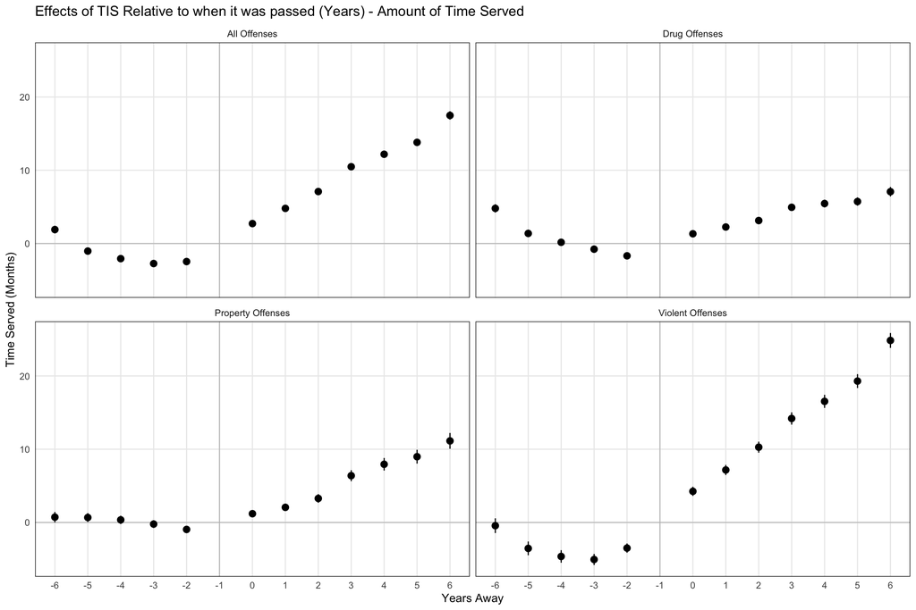

Figure 9.1: Event study with controls – Time Served – Non-clustered Standard Errors

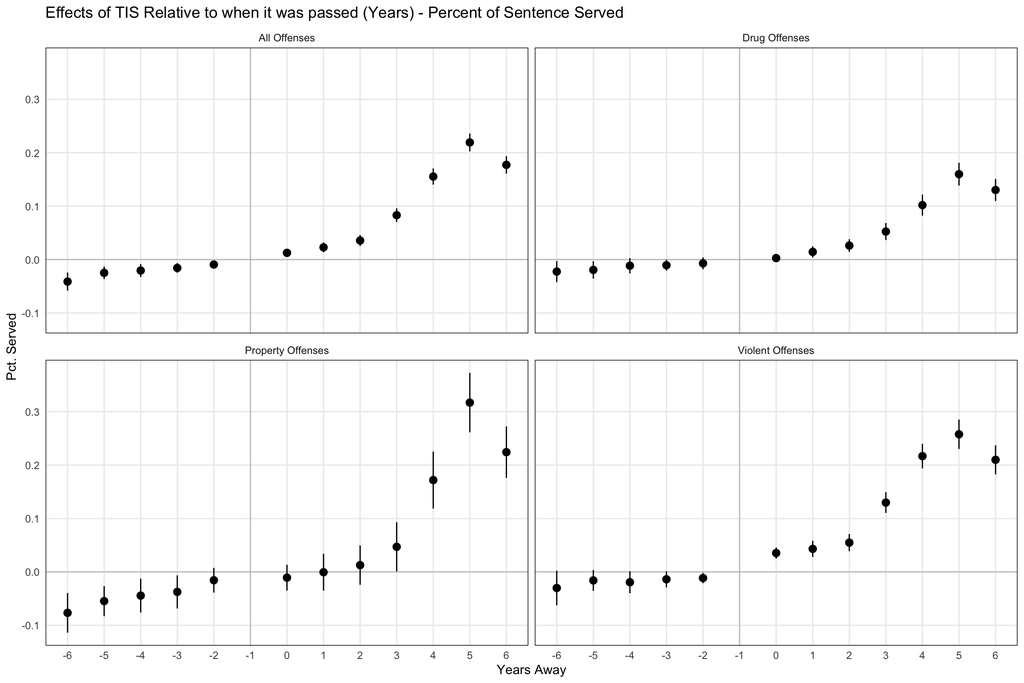

Figure 9.2: Event study with controls – Proportion Seved – Non-clustered Standard Errors

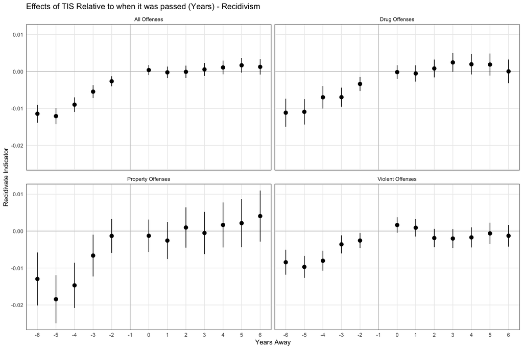

Figure 9.3: Event study with controls – Recidivism – Non-clustered Standard Errors

## 9.3 Appendix - Clement

beta estimates a weighted sum of 74 ATTs. 46 ATT receive a positive weight, and 28 receive a negative weight. The sum of the positive weights is equal to 1.709505. The sum of the negative weights is equal to -0.709505. beta is compatible with a DGP where the average of those ATT is equal to 0, while their standard deviation is equal to 0.275078. beta is compatible with a DGP where those ATT all are of a different sign than beta, while their standard deviation is equal to 0.591563.

Clement Weights

| Year | TIS Year | Weight |
| --- | --- | --- |
| 1990 | 1994 | 0.0000000 |
| 1991 | 1994 | 0.0000000 |
| 1992 | 1994 | 0.0000000 |
| 1993 | 1994 | 0.0000000 |
| 1994 | 1994 | 0.0187398 |
| 1995 | 1994 | 0.3295289 |
| 1996 | 1994 | 0.0478409 |
| 1997 | 1994 | 0.0492967 |
| 1998 | 1994 | 0.0254387 |
| 1999 | 1994 | 0.0000009 |
| 2000 | 1994 | -0.0148526 |
| 2001 | 1994 | -0.0170305 |
| 2002 | 1994 | -0.0207034 |
| 2003 | 1994 | -0.0238194 |
| 2004 | 1994 | -0.0252899 |
| 2005 | 1994 | -0.0673188 |
| 2006 | 1994 | -0.1126508 |
| 2007 | 1994 | -0.1113872 |
| 1990 | 1995 | 0.0000000 |
| 1991 | 1995 | 0.0000000 |
| 1992 | 1995 | 0.0000000 |
| 1993 | 1995 | 0.0000000 |
| 1994 | 1995 | 0.0000000 |
| 1995 | 1995 | -0.1120168 |
| 1996 | 1995 | 0.0912413 |
| 1997 | 1995 | 0.0934528 |
| 1998 | 1995 | 0.0703990 |
| 1999 | 1995 | 0.0515767 |
| 2000 | 1995 | 0.0326984 |
| 2001 | 1995 | 0.0326260 |

[output cut: 96 more lines]